# RandomForest

Lars Vatten

2023-04-12

```r
d.heart <- read.csv("heart.csv")

str(d.heart)
```

```
## 'data.frame':    918 obs. of  12 variables:
##  $ Age           : int  40 49 37 48 54 39 45 54 37 48 ...
##  $ Sex           : chr  "M" "F" "M" "F" ...
##  $ ChestPainType : chr  "ATA" "NAP" "ATA" "ASY" ...
##  $ RestingBP     : int  140 160 130 138 150 120 130 110 140 120 ...
##  $ Cholesterol   : int  289 180 283 214 195 339 237 208 207 284 ...
##  $ FastingBS     : int  0 0 0 0 0 0 0 0 0 0 ...
##  $ RestingECG    : chr  "Normal" "Normal" "ST" "Normal" ...
##  $ MaxHR         : int  172 156 98 108 122 170 170 142 130 120 ...
##  $ ExerciseAngina: chr  "N" "N" "N" "Y" ...
##  $ Oldpeak       : num  0 1 0 1.5 0 0 0 0 1.5 0 ...
##  $ ST_Slope      : chr  "Up" "Flat" "Up" "Flat" ...
##  $ HeartDisease  : int  0 1 0 1 0 0 0 0 1 0 ...
```

```r
head(d.heart)
```

```
##   Age Sex ChestPainType RestingBP Cholesterol FastingBS RestingECG MaxHR
## 1  40   M           ATA       140         289         0     Normal   172
## 2  49   F           NAP       160         180         0     Normal   156
## 3  37   M           ATA       130         283         0         ST    98
## 4  48   F           ASY       138         214         0     Normal   108
## 5  54   M           NAP       150         195         0     Normal   122
## 6  39   M           NAP       120         339         0     Normal   170
##   ExerciseAngina Oldpeak ST_Slope HeartDisease
## 1              N     0.0       Up            0
## 2              N     1.0     Flat            1
## 3              N     0.0       Up            0
## 4              Y     1.5     Flat            1
## 5              N     0.0       Up            0
## 6              N     0.0       Up            0
```

Change datatype of response variable “HeartDisease” to factor, and make it more readable. Also transform character variables to factor variables.

```r
d.heart$HeartDisease <- ifelse(d.heart$HeartDisease == 1, yes="Y", no="N")

d.heart$HeartDisease <- as.factor(d.heart$HeartDisease)
d.heart$Sex <- as.factor(d.heart$Sex)
d.heart$ChestPainType <- as.factor(d.heart$ChestPainType)
d.heart$RestingECG <- as.factor(d.heart$RestingECG)
d.heart$ExerciseAngina <- as.factor(d.heart$ExerciseAngina)
d.heart$ST_Slope <- as.factor(d.heart$ST_Slope)

str(d.heart)
```

```
## 'data.frame':    918 obs. of  12 variables:
##  $ Age           : int  40 49 37 48 54 39 45 54 37 48 ...
##  $ Sex           : Factor w/ 2 levels "F","M": 2 1 2 1 2 2 1 2 2 1 ...
##  $ ChestPainType : Factor w/ 4 levels "ASY","ATA","NAP",..: 2 3 2 1 3 3 2 2 1 2 ...
##  $ RestingBP     : int  140 160 130 138 150 120 130 110 140 120 ...
##  $ Cholesterol   : int  289 180 283 214 195 339 237 208 207 284 ...
##  $ FastingBS     : int  0 0 0 0 0 0 0 0 0 0 ...
##  $ RestingECG    : Factor w/ 3 levels "LVH","Normal",..: 2 2 3 2 2 2 2 2 2 2 ...
##  $ MaxHR         : int  172 156 98 108 122 170 170 142 130 120 ...
##  $ ExerciseAngina: Factor w/ 2 levels "N","Y": 1 1 1 2 1 1 1 1 2 1 ...
##  $ Oldpeak       : num  0 1 0 1.5 0 0 0 0 1.5 0 ...
##  $ ST_Slope      : Factor w/ 3 levels "Down","Flat",..: 3 2 3 2 3 3 3 3 2 3 ...
##  $ HeartDisease  : Factor w/ 2 levels "N","Y": 1 2 1 2 1 1 1 1 2 1 ...
```

See hoe the responsevariable is distributed in the data:

```r
table(d.heart$HeartDisease)
```

```
##
##   N   Y
## 410 508
```

Split into training and test set:

```r
training_set_size <- floor(0.8 * nrow(d.heart))
train_ind <- sample(seq_len(nrow(d.heart)), size = training_set_size)
train <- d.heart[train_ind, ]
test <- d.heart[-train_ind, ]
```

Random forest:

```r
model <- randomForest(HeartDisease ~ ., data = train, importance = TRUE)

model
```

```
##
## Call:
##  randomForest(formula = HeartDisease ~ ., data = train, importance = TRUE)
##                Type of random forest: classification
##                      Number of trees: 500
## No. of variables tried at each split: 3
##
##         OOB estimate of  error rate: 14.58%
## Confusion matrix:
##     N   Y class.error
## N 261  64   0.1969231
## Y  43 366   0.1051345
```

Predict on test set:

```r
prediction <- predict(model, test)
```

Assess prediction:

```r
confusionMatrix <- confusionMatrix(data = prediction, reference = test$HeartDisease)
confusionMatrix
```

```
## Confusion Matrix and Statistics
##
##           Reference
## Prediction  N  Y
##          N 71 16
##          Y 14 83
##
##                Accuracy : 0.837
##                  95% CI : (0.7755, 0.8872)
##     No Information Rate : 0.538
##     P-Value [Acc > NIR] : <2e-16
##
##                   Kappa : 0.6726
##
##  Mcnemar's Test P-Value : 0.8551
##
##             Sensitivity : 0.8353
##             Specificity : 0.8384
##          Pos Pred Value : 0.8161
##          Neg Pred Value : 0.8557
##              Prevalence : 0.4620
##          Detection Rate : 0.3859
##    Detection Prevalence : 0.4728
##       Balanced Accuracy : 0.8368
##
##        'Positive' Class : N
##
```

Now we fiddle with the parameters of the model to see if it yields a better model.

First we investigate the number of trees in the forest. The number of trees is not a tuning parameter, the question is just whether we have enough trees for optimal classification, and of course we want as few trees as possible within this range to keep the complexity down.

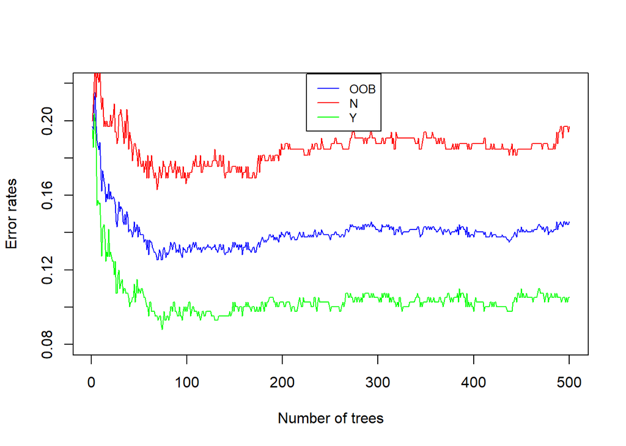

```r
plot(model$err.rate[,1], type="l", ylim = c(0.08, 0.22), ylab="Error rates", xlab = "Number of trees", col="blue")
lines(model$err.rate[,2], col="red")
lines(model$err.rate[,3], col="green")
legend(225, 0.225, legend=c("OOB", "N", "Y"), col=c("blue", "red", "green"), lty=1, cex=0.8)
```

Observing the plot, it seems like the error rates stabilize at around 100 trees, which means we can save complexity by reducing the number of trees frok 500 to 100 without any loss of precision in the model.

We create a new forest with 100 trees to confirm that the resulting prediction is just as good as with 500 trees:

```r
adjustedModel <- randomForest(HeartDisease ~ ., data = train, ntree=100, importance = TRUE)

adjustedModel
```

```
##
## Call:
##  randomForest(formula = HeartDisease ~ ., data = train, ntree = 100,      importance = TRUE)
##                Type of random forest: classification
##                      Number of trees: 100
## No. of variables tried at each split: 3
##
##         OOB estimate of  error rate: 13.49%
## Confusion matrix:
##     N   Y class.error
## N 264  61  0.18769231
## Y  38 371  0.09290954
```

```r
adjustedPrediction <- predict(adjustedModel, test)

confusionMatrix2 <- confusionMatrix(data = adjustedPrediction, reference = test$HeartDisease)
confusionMatrix2
```

```
## Confusion Matrix and Statistics
##
##           Reference
## Prediction  N  Y
##          N 67 14
##          Y 18 85
##
##                Accuracy : 0.8261
##                  95% CI : (0.7634, 0.8779)
##     No Information Rate : 0.538
##     P-Value [Acc > NIR] : <2e-16
##
##                   Kappa : 0.649
##
##  Mcnemar's Test P-Value : 0.5959
##
##             Sensitivity : 0.7882
##             Specificity : 0.8586
##          Pos Pred Value : 0.8272
##          Neg Pred Value : 0.8252
##              Prevalence : 0.4620
##          Detection Rate : 0.3641
##    Detection Prevalence : 0.4402
##       Balanced Accuracy : 0.8234
##
##        'Positive' Class : N
##
```

Now we investigate whether we consider the optimal number of variables in each split in the trees. The default value used in the previous models is 3, which corresponds to the floored square root of the number of predictors. To find the optimal value, we test all possible number of predictors, which in our case is 1 through 11. In each iteration, we store the OOB error rate at the final iteration, that is when the forest is made up of all 100 trees.

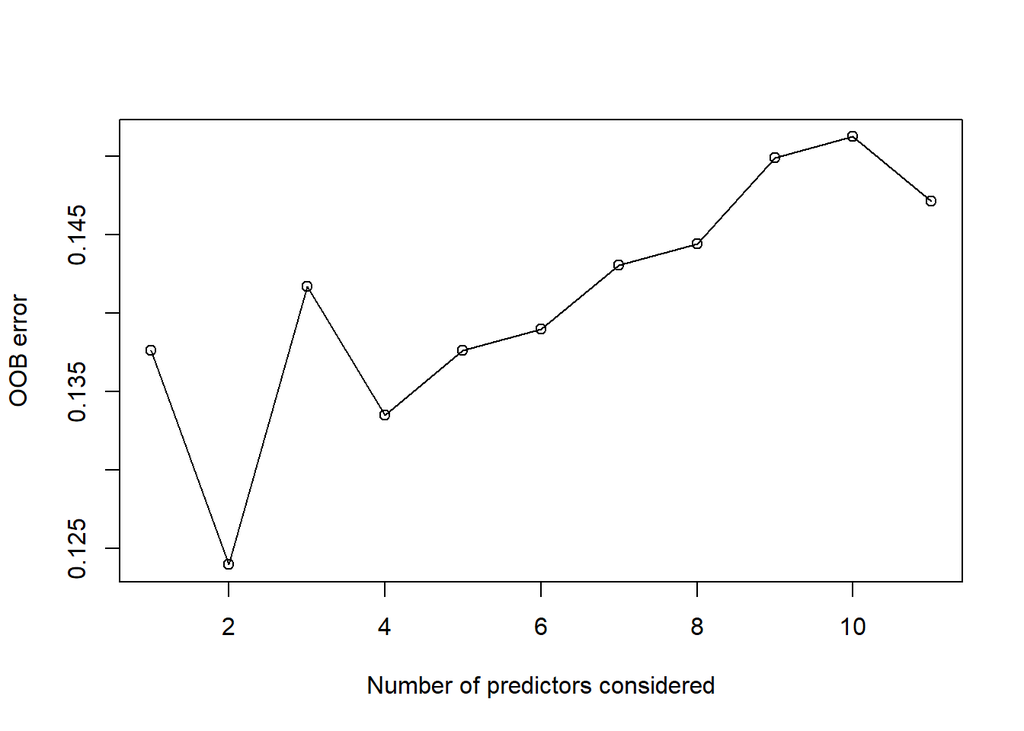

```r
oobValues = vector(length=11)


for(i in 1:11) {
  newModel <- randomForest(HeartDisease ~ ., data = train, mtry=i, ntree=100, proximity = TRUE)
  oobValues[i] <- newModel$err.rate[nrow(newModel$err.rate), 1]
}
plot(oobValues, type = "o", xlab="Number of predictors considered", ylab="OOB error")
```

Observing the plot, the OOB error does vary depending on the number of predictors that are considered in each tree split. However, running the experiment multiple times shows that there is no unique optimal value, since the optimal value changes every iteration. Hence, we just stick with the default value of $\texttt{mtry}=\lfloor\sqrt{p}\rfloor=3$, where $p$ is the number of predictors.

In addition to creating a predictive model, we want the model to say something about the relation between the response and the different covariates. The $\texttt{randomForest()}$ library has a built in function that approximates how separate predictors affects the accuracy of the model and the impurity of the roots in the trees of the model.

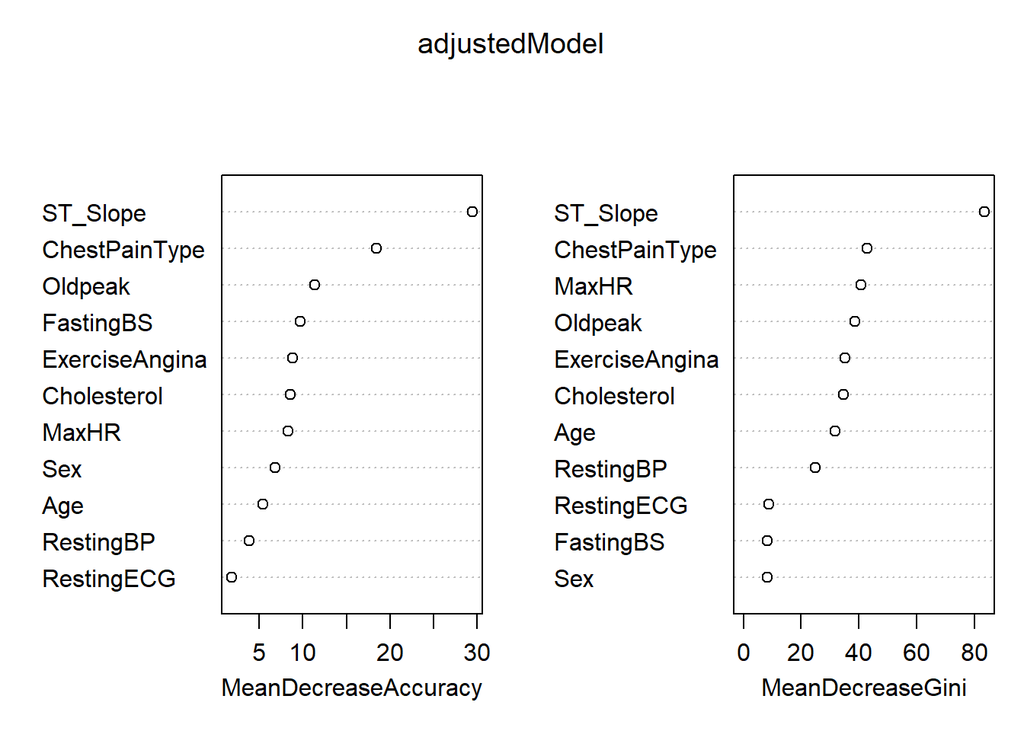

```r
varImpPlot(adjustedModel)
```

Examining the plots, it seems like the **ST_Slope** and **ChestPainType** variables is most important for creating a good model, indicating that they have a strong correlation with the response variable. We can make examine their importance further by using the $\texttt{partialPlot()}$ function, which gives a graphical depiction of the marginal effect a variable has on the class probability.

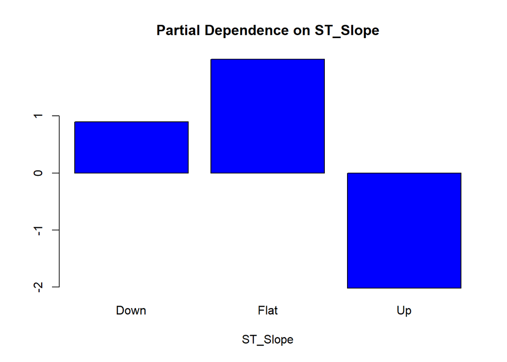

```r
partialPlot(adjustedModel, train, ST_Slope, "Y")
```

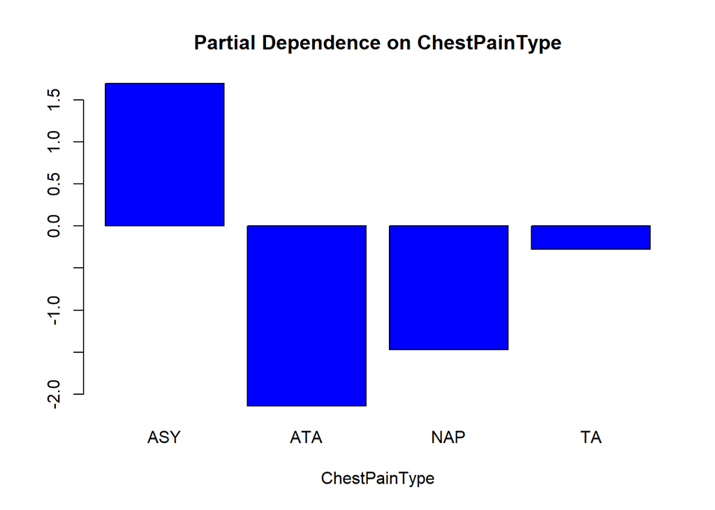

```r
partialPlot(adjustedModel, train, ChestPainType, "Y")
```

For the sake of experimenting, we also also check the partial dependence on the **Age** variable, which we have a better intuitive understanding of. Based on our own experience and knowledge, it is reasonable to assume that higher age should correspond to higher risk of heart disease, and we can use this knowledge to check whether the model does actually yield a logical relationship between the response and the predictors.

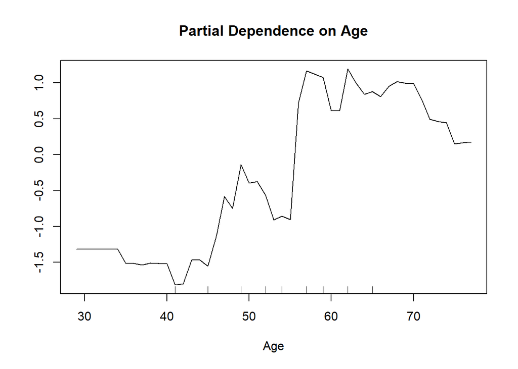

```r
partialPlot(adjustedModel, train, Age, "Y")
```

Indeed, it seems like the model is more likely to predict heart disease for older people.

Another way to study inference from a random forest is to look at the individual trees in the forest, and see which variables is more often used to split the data.